# Reproducible Data, Week 2, Assignment 1

## Imputing missing values

Up to now, based on the above data analysis choices, we’ve been working with the ‘clean’ data - ie no missing values. The next section requires us to take those into account and figure out a way to fill in the missing data. So let’s calculate and report how much missing data (total NAs) there is from the original data set?

```r
sum(is.na(AMD.Data))
```

```
## [1] 2304
```

Now let’s “Devise a strategy for filling in all of the missing values in the dataset. The strategy does not need to be sophisticated. For example, you could use the mean/median for that day, or the mean for that 5-minute interval, etc.” "

Just for the sake of this assignment I’ve chosen the mean - it would make the most sense in this author’s opinion for this particular type of case. (ie the mean of the daily interval). The assignment hints at making a “new dataset that is equal to the original dataset but with the missing data FILLED IN - so we cannot use AMD.Data.NALess since that dataset simply ignores or removes the NAs.

```r
# create a new dataset that is equal to the original but with the missing data filled in.
ImputedAMD <- merge(AMD.Data, AvgDailyActPat, by= "interval", suffixes = c("", ".y"))
NAvals <- is.na(ImputedAMD$steps)
ImputedAMD$steps[NAvals] <- ImputedAMD$steps.y[NAvals]
ImputedAMD <- ImputedAMD[, c(1:3)]
```

Now to make the plot - using ggplot again here.

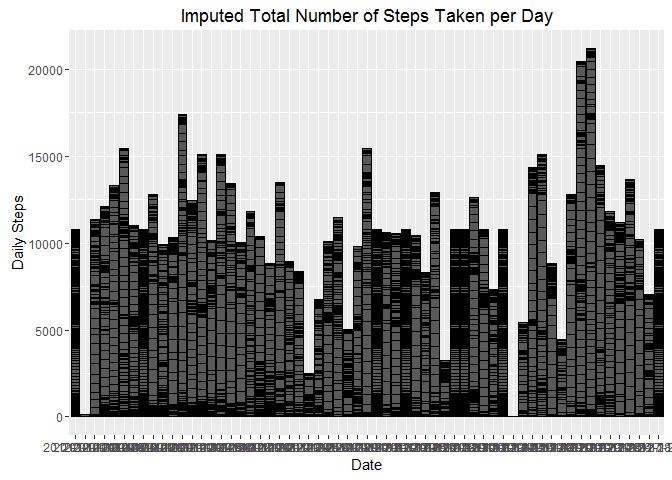

```r
# make a histogram of the total number of steps taken each day with the above new dataset.
g2 <- ggplot(ImputedAMD, aes(date,steps))
plot2 <- g2+geom_bar(stat="identity", color = "black")+labs(title="Imputed Total Number of Steps Taken per Day", x="Date", y="Daily Steps")
plot2
```

```r
totalimputedsteps <- tapply(ImputedAMD$steps, ImputedAMD$date, FUN = sum)
mean(totalimputedsteps)
```

```
## [1] 10766.19
```

```r
median(totalimputedsteps)
```

```
## [1] 10766.19
```

#### Q: Do these values differ from the estimates from the first part of the assignment?

Yes. So the result shows that the new mean is less than the old one by roughly 4 steps (10766.19 - 10770). And the new Median is is higher by roughly 6 teps (10766.19 - 10760).

#### Q: What is the impact of imputing missing data on the estimates of the total daily number of steps?

It is Hardly a noticeable change per instance, but over a longer time scale (eg a month) the differences will really add up :).

## Are there differences in activity patterns between weekdays and weekends?

So in the next part of the assignment we must determing if our subject is more active during the weekend or the weekdays. The tip provided in the assignment is to use the weekdays() function (if you’ve never used before, like me, or heard about it just type ?weekdays and you’ll get some info on it)

In order for R to treat the “date” variable as a date class object, we must c convert it. Earlier we saw it was a character class. To make it a date class:

NOTE: as I really struggled with this part, I eventually had to look at many many solutions and suggestions which were posted online - many which were too advanced for my level of R, but I found one which I eventually used as a guide [here][1]. [1]:http://rstudio-pubs-static.s3.amazonaws.com/22372_0b43aa70ec2e4146b17b7c05d2b5245f.html

```r
ImputedAMDdays <- ImputedAMD
Weekenddays <- weekdays(as.Date(ImputedAMDdays$date)) %in% c("Saturday", "Sunday")
ImputedAMDdays$daytype <- "Weekday"
ImputedAMDdays$daytype[Weekenddays == TRUE] <- "Weekend"
ImputedAMDdays$daytype <- as.factor(ImputedAMDdays$daytype)

# test it out

head(ImputedAMDdays)
```

```
##   interval    steps       date daytype
## 1        0 1.716981 2012-10-01 Weekday
## 2        0 0.000000 2012-11-23 Weekday
## 3        0 0.000000 2012-10-28 Weekend
## 4        0 0.000000 2012-11-06 Weekday
## 5        0 0.000000 2012-11-24 Weekend
## 6        0 0.000000 2012-11-15 Weekday
```

Next, we are requested to “Make a panel plot containing a time series plot (i.e. type =”l“) of the 5-minute interval (x-axis) and the average number of steps taken, averaged across all weekday days or weekend days (y-axis).”

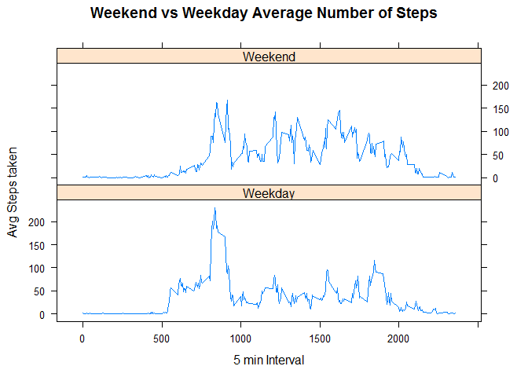

```r
# daily average steps by daytype
AvgStepsByDayType <- aggregate(steps ~ interval + daytype, ImputedAMDdays, mean)
names(AvgStepsByDayType)[3] <- "Avg_Steps"
library(lattice)
plot3 <- xyplot(Avg_Steps ~ interval | daytype, AvgStepsByDayType, type="l", layout=c(1,2), main = "Weekend vs Weekday Average Number of Steps", xlab="5 min Interval", ylab="Avg Steps taken")
plot3
```